# Fishing Communities in the face of Climate Change: Coastal Maine, A Case Study

Emma Weed

12/3/2019

### Purpose Statement

I wanted to graph the water temperatures in coastal Maine over time to highlight the implications of climate change on coastal fishing communities.

In this blog I will examine the vulnerability and research potential for the continual perseverance of coastal fishing communities in the face of climate change. As the climate crisis progresses many vulnerable populations are at risk for loss of livelihood, life and culture through the reduction of fishing yields. Fishing communities pose a unique challenge as our society attempts to adapt in the face of natural disaster and changing conditions. These communities experience an intersection of oppressive functions of changing global temperatures; including exposure, resource dependence and lack of adaptive capacity. Compounding anthropocentric impacts are magnified by climate change. The impact of climate change on the fishing industry could be the loss of food security for nearly 12 million people worldwide (Morzaria-Luna, 2013). I will discuss how each of these intersect to reduce the ability for these historic communities to persist in the future. I chose to examine the Maine Coast as a precursor to my thesis project which plans to focus on fishing communities in Trinidad and Tobago.

### My Positionality

I am personally invested in this project due to growing up in a fishing community on an island off the coast of Maine. While extremely environmentally privileged, poverty, addiction, lack of infrastructure and lack of education plague the area. As I grew I would hear anecdotal evidence about the migration of lobsters, my (and many others) family’s livelihood. Year after year the lobsters failed to arrive as they had for generations, my grandfather, while no scientist, would often remark that the lobsters were ‘moving.’ He had never seen anything like it in his 70+ years of hauling lobster traps from the depths of the Atlantic, this anecdotal evidence was not respected by the scientists and research seemed to undermine or ignore the voice of the fishermen in the environmental regulation conversation.

In the face of criticism and loss of livelihood the fishermen doubled down on their need to depend on fossil fuels and continue to fish while rejecting climate change as a survival mechanism. Environmentalists were seen as the enemy, privileged and lofty governmental agents blaming my family for things far out of our control and chastising them for a way of life known for generations. Environmental regulation was seen as the enemy to the industry, an enforcement of federal policy in a libertarian area. Regardless of the long-term effects of climate change, communities like mine live in a fragile position dependent on the ocean. When environmental regulation was discussed and implemented in politics it was usually referring to commercial fishing and the detriment they have on ecosystems, despite the fact that artisanal or small-scale fishers represent more than 90% of the worlds fishermen, mostly in developing countries or disadvantaged communities (Badjeck, 2010). Every season can make or break your ability to feed your family, heat your house in the winter and continue to operate one’s boat. In addition to this the migration patterns of lobsters mean that the season is plentiful for four months and dire for eight months. If those short four months are wasted or unfruitful, one will undoubtedly suffer for the remaining eight. These personal experiences with the disjunct between science and community advocacy inspired me towards environmental justice through collective empowerment and social justice.

### Exposure

While climate change will affect the world as a whole in major ways some communities are at higher risks of exposure to these effects than others. Fishing communities, like others, vary in their exposure to natural patterns, technological access, economic infrastructure, social capital and the presence (or lack of) formal institution. Some communities, like the Bangladeshi coastal fishing communities, are already at a high risk for cyclone as well as in a fragile socioeconomic position (Islam, 2013). Climate change will serve to exacerbate and magnify the exposure already experienced by these communities. Key components of vulnerability may differ across each individual community, even in areas similar in certain aspects (Morzaria-Luna, 2013).

In addition to the natural systems at work in their communities these areas are extremely vulnerable to other anthropogenic interference. This includes pollution, overfishing, habitat degradation and government infrastructure. One can see this in Alaska, while the communities are somewhat similar anthropogenic influences can determine whether or not they can adapt to the new conditions arising from climate change. As climate change progression these communities will be impacted in a variety of ways including sea level rise, ocean acidification, increased severity of extreme events, modification of thermal structure and increased climatic variability.

### Resource Dependence

The historic and infrastructure of an area will determine how dependent the community is on fishing on economic, hydra-cultural and social levels. While a community may have been historically successful as a fishing-dependent area this success cannot remain when climate change, dependence, and environmental history intersect. Dependence on the fishing industry can come in various forms. This includes one’s ability to find work and can be compounded by persistent social justice and environmental issues; “climate change is interacting with other anthropogenic impacts, such as pollution and habitat destruction that are currently negatively affecting the marine environment. Although not well-documented across all marine regions of the U.S., evidence to date suggests marine resource-dependent communities are likely to experience substantial socio-economic impacts from climate change, negative in some areas and positive in others” (Himes-Cornell, 2014). Communities like those in the Niger Delta and Mumbai are dependent upon the fishing industry. These places are often trapped in a cycle of fishery decline. They are unable to organize new infrastructure around a new industry. Instead overfishing and resource dependence is compounded to cause economic decline in the long run.

This resource dependence can clearly be seen in the Maine communities. These individuals have relied on the industry for generations. The bulk of our communities, economy and social capital is invested into fishing and the materials needed for this. In the past 30 years the industry has slowly declined. Small salvations, like opening of scallop zones, or changing of regulation, has allowed Maine to adapt in small ways. These adaptations are insufficient and now the economy is artificially supported towards an economic infrastructure that is not viable. The pages of the sale newspapers are now flooded with the sale of boats, gear and the once-coveted fishing licenses. The market is saturated with nobody wanting to leave but nobody able to continue the fishing legacy.

### Adaptive Capacity: Limits and Barriers

As the climate and society becomes less hospitable to fishing communities they will attempt to adapt. The ability of a community to adapt to these influences is referred to as their adaptive capacity. A communities’ adaptive capacity is determined by many of the influences that make it more or less susceptible to being influenced in the first place. Those who are most disadvantaged already are unable to make adaptations to salvage some part of the fishing infrastructure.

In Maine the presence of the SEA Grant from the U.S. Government provides resources and infrastructure behind sustaining the coastal communities and enabling them to continue to succeed. As communities adapt they may change spatial/temporal distribution of fishing, change of species fished, change of location of fish landing/processing and change of how these communities treat and interact with their prey. In Maine this can be seen in the killing of seals. Seals are the natural predators of the lobster. Instead of understanding the full effects of climate change fishermen have blamed this population for the decline in economic prosperity. This means that fishermen are more likely to carry firearms on their boats. This also means that fishermen are more prone to violent territory wars. With less money being made implications of loss of income are exasperated. I remember sitting on my father’s boat many times when we would go out to ‘cut.’ ‘Cutting’ is the process of sinking the traps of those who have infringed on your territory or in some way disrespected you as a fishermen. Often this would occur with outsiders and ‘cutting’ was an essential piece of social infrastructure. If someone infringed on your territory and you didn’t ‘cut’ you were weak and others would follow suit. I recall riding along while we ran the 44ft boat up along buoy line after buoy line, cutting close to the full 1200 of someone’s traps. I can’t remember the exact social violations however it included: cutting line at the bait dock, following someone’s pattern too closely, not respecting someone’s territory who has been there longer or even getting a license in the wrong zone with the wrong family. I expect violence and destruction of property to only increase as the lobster prices and populations become more rare.

### My Graphs

##### Graph 1: Ocean Surface Temperatures (SST) In Coastal Maine 2015-2018

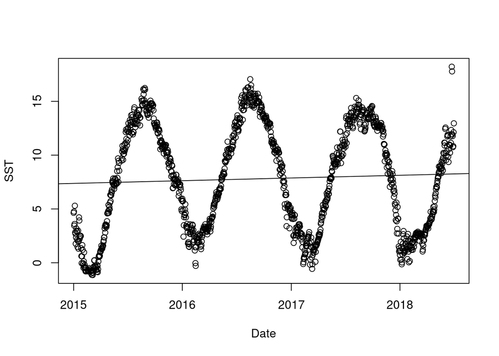

Graph 1 Shows the slight increase in temperatures over time in sea surface temperatures in coastal Maine. This indicates that the temperature of the sea has gone up over this time period. While this may not be indicative of larger patterns it does show a difference in temperature. This difference in temperature over a three year period can be extremely harmful to the fishermen. While climate change is posed as a long-term crisis, lobstermen are reliant on each fishing season to maintain their income. This increase can pose socio-economic stress over time.

### Citizen Science and Collective Action

As I begin my research into this topic it is obvious how hard it is to acquire and analyze the data and information provided by the agencies that manage surveillance of ocean surface temperatures. The accessibility of the data and its interpretation can be integral to a community’s ability to understand, adapt and mitigate what is happening in their environment. I used data collected from NOAA. In order to collect this data I needed to submit a request, it was not in a public domain. From this request NOAA would use my email to determine if I was qualified to have access to the data. In addition to this while NOAA provides graphs of ocean temperatures over time they will only provide data for the past three years to the public. They obviously have the data and for it to not be in the public domain only fuels skepticism and does not permit individuals or fishermen access to data which determines their livelihood. In my opinion the first step towards enabling citizen science and prosperity in these areas is to empower the fishermen to access and relate to the data. Implications of lack of collective action have socio-economic stressors that will only increase community violence and tensions. I think empowerment of environmentalism towards a fishing infrastructure is the only hoope for these communities as the climate crisis takes hold.